# Temple Summer Group Assignment 2

My Name Here

June 09, 2020

Rev up the libraries

```r
library(reshape2)
library(tidyverse)
library(car) #regression diagnostics, lots of other regression functions
library(psych)
library(corrplot)
library(RColorBrewer)
library(viridis) #specific color palette
library(janitor) #cleans up character strings -- upper to lower, etc.
library(ggm)
library(ltm) #point biserial correlations
library(cocor) #contrasts two correlations
library(lessR)
library(plotly)
jamie.theme <- theme_bw() + theme(axis.line = element_line(colour = "black"), panel.grid.minor = element_blank(), panel.grid.major = element_blank(), panel.border = element_blank(), panel.background = element_blank(), legend.title= element_blank())
```

Read in the data (curse_short.csv). Make sure to specify that the first column of the raw data gets read in as row names. Use the clean_names() function to close up spaces, etc. Print the dataframe and then print the structure of the dataframe. Make sure you omit missing data listwise (hint use na.omit)

|  | curse_quality | concreteness | frequency | valence | arousal | dominance | body_other |
| --- | --- | --- | --- | --- | --- | --- | --- |
| alcohol | 1.977011 | 586 | 16.57 | 4.11 | 5.17 | 4.00 | 0 |
| ambulance | 1.551724 | 586 | 22.41 | 3.71 | 5.33 | 3.29 | 0 |
| animal | 3.678161 | 566 | 45.49 | 7.06 | 4.30 | 5.72 | 0 |
| ankle | 1.666667 | 615 | 8.02 | 5.40 | 3.11 | 5.58 | 1 |
| ant | 2.724138 | 585 | 5.35 | 3.90 | 3.27 | 5.30 | 0 |
| apartment | 1.482759 | 621 | 83.04 | 5.72 | 3.80 | 5.33 | 0 |
| ape | 4.482759 | 618 | 9.67 | 5.21 | 4.25 | 5.38 | 0 |
| apple | 2.137931 | 578 | 23.67 | 6.62 | 3.52 | 6.44 | 0 |
| arm | 2.149425 | 624 | 65.41 | 5.44 | 3.44 | 6.02 | 1 |
| arrow | 2.413793 | 600 | 7.84 | 5.24 | 3.91 | 5.53 | 0 |

[output cut: 471 more lines]

```
## 'data.frame':    481 obs. of  7 variables:
##  $ curse_quality: num  1.98 1.55 3.68 1.67 2.72 ...
##  $ concreteness : int  586 586 566 615 585 621 618 578 624 600 ...
##  $ frequency    : num  16.57 22.41 45.49 8.02 5.35 ...
##  $ valence      : num  4.11 3.71 7.06 5.4 3.9 5.72 5.21 6.62 5.44 5.24 ...
##  $ arousal      : num  5.17 5.33 4.3 3.11 3.27 3.8 4.25 3.52 3.44 3.91 ...
##  $ dominance    : num  4 3.29 5.72 5.58 5.3 5.33 5.38 6.44 6.02 5.53 ...
##  $ body_other   : int  0 0 0 1 0 0 0 0 1 0 ...
##  - attr(*, "na.action")= 'omit' Named int [1:6] 11 69 155 169 223 381
##   ..- attr(*, "names")= chr [1:6] "aspirin" "cafe" "feet" "fort" ...
```

Inspect correlations and distributions by generating a scatterplot matrix. Use Spearman correlations (hint: use pairs panels)

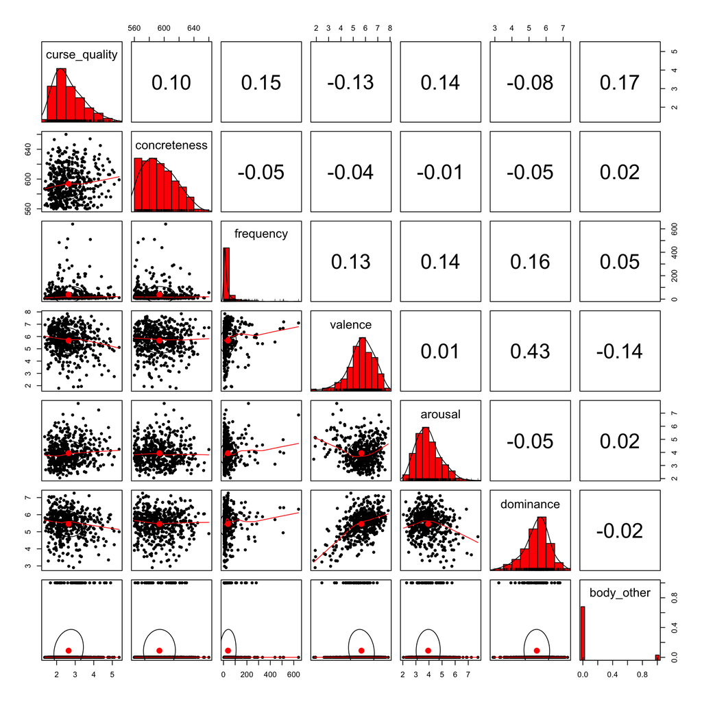

Generate a corrplot across all the variables in the cursing dataset, clustering the variables by similarity (hint, use hclust and the corrplot package)

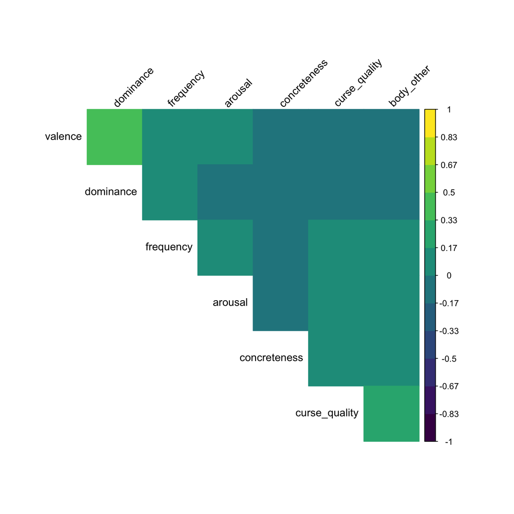

Produce a journal quality Spearman correlation matrix using corrplot among all the variables in the cursing dataset. Change your background to gray and tilt the labels 45 degrees

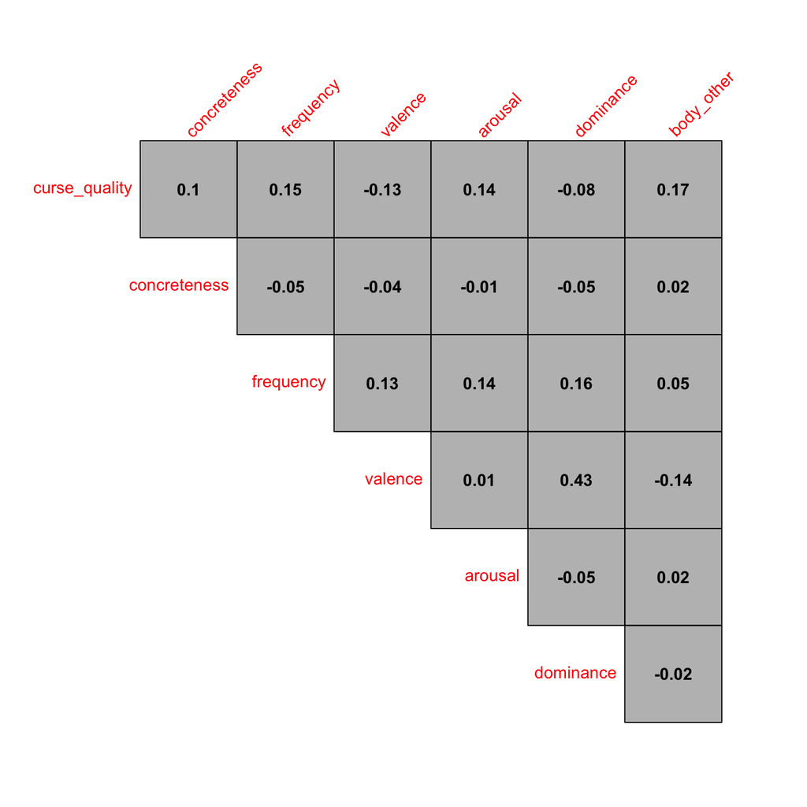

What is the Spearman correlation and its correponding p-value between Curse Quality and Arousal?

```
##
##  Spearman's rank correlation rho
##
## data:  all$curse_quality and all$arousal
## S = 16043152, p-value = 0.003007
## alternative hypothesis: true rho is not equal to 0
## sample estimates:
##       rho
## 0.1350169
```

What is the point biserial correlation between body_other and curse_quality?

```
## [1] -0.1596642
```

Compute the Pearson correlation between curse_quality and valence. Then compute the partial correlation between curse_quality and valence controlling for dominance. Hint: you need the sample size!

```
##
##  Pearson's product-moment correlation
##
## data:  all$curse_quality and all$valence
## t = -3.3016, df = 479, p-value = 0.001033
## alternative hypothesis: true correlation is not equal to 0
## 95 percent confidence interval:
##  -0.23543446 -0.06056756
## sample estimates:
##        cor
## -0.1491671
```

```
## [1] -0.110228
```

```
## $tval
## [1] -2.424714
##
## $df
## [1] 478
##
## $pvalue
## [1] 0.01569014
```

Create a scatterplot of curse_quality by valence fitting a loess function to the data. Apply whatever aesthetics you like.  
Then test for whether the relationship is linear using the polynomial function. Is the relationship linear, quadratic, or cubic?

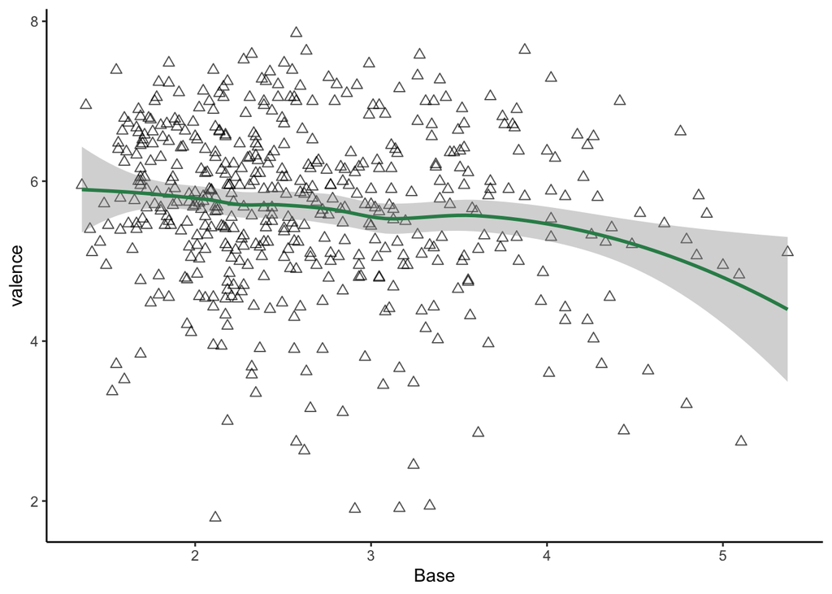

```
##
## Call:
## lm(formula = valence ~ poly(curse_quality, 3, raw = T), data = all)
##
## Residuals:
##     Min      1Q  Median      3Q     Max
## -3.9475 -0.5615  0.0822  0.7199  2.1802
##
## Coefficients:
##                                  Estimate Std. Error t value   Pr(>|t|)
## (Intercept)                       7.66248    1.58021   4.849 0.00000168
## poly(curse_quality, 3, raw = T)1 -1.93226    1.66229  -1.162      0.246
## poly(curse_quality, 3, raw = T)2  0.63688    0.55362   1.150      0.251
## poly(curse_quality, 3, raw = T)3 -0.07263    0.05847  -1.242      0.215
##
## Residual standard error: 1.042 on 477 degrees of freedom
## Multiple R-squared:  0.02662,    Adjusted R-squared:  0.0205
## F-statistic: 4.348 on 3 and 477 DF,  p-value: 0.004899
```